# Projekt (plik 1)

Radosław Mocarski

25 03 2024

# Przeprowadzić dość zwięzłą EDA dla posiadanego zestawu danych.

## Przygotować dane – wyznaczyć częstość strat dla każdego roku (dla każdej kategorii zdarzeń operacyjnych).

```r
dane <- read.csv("plik1.csv",row.names = 1)
library(dplyr)
library(ggplot2)
library(fitdistrplus)
set.seed(223)

print("Sprawdzenie struktury danych")
```

```
## [1] "Sprawdzenie struktury danych"
```

```r
str(dane)
```

```
## 'data.frame':    7702 obs. of  3 variables:
##  $ rok   : int  1989 1989 1989 1989 1989 1989 1989 1989 1989 1990 ...
##  $ strata: num  10 10 10 10 10 10 10 10 10 10 ...
##  $ linia : chr  "Buss_Distr" "Buss_Distr" "Buss_Distr" "Buss_Distr" ...
```

```r
print("Podsumowanie danych numerycznych")
```

```
## [1] "Podsumowanie danych numerycznych"
```

```r
summary(dane$rok)
```

```
##    Min. 1st Qu.  Median    Mean 3rd Qu.    Max.
##    1989    1997    2006    2006    2015    2023
```

```r
summary(dane$strata)
```

```
##     Min.  1st Qu.   Median     Mean  3rd Qu.     Max.
##       10      872     4553    17551    30869 16362367
```

```r
print("Sprawdzenie unikalnych wartości w zmiennej 'linia'")
```

```
## [1] "Sprawdzenie unikalnych wartości w zmiennej 'linia'"
```

```r
unique(dane$linia)
```

```
## [1] "Buss_Distr"  "Com_Ban"     "Damage"      "Empl_Pract"  "Execut_Del"
## [6] "External_Fr" "Internal_Fr"
```

```r
srednia_wystapien <- aggregate(strata ~ rok, data = dane, FUN = length)
print("Podsumowanie ilości wydarzeń generujących straty rocznie")
```

```
## [1] "Podsumowanie ilości wydarzeń generujących straty rocznie"
```

```r
summary(srednia_wystapien$strata)
```

```
##    Min. 1st Qu.  Median    Mean 3rd Qu.    Max.
##   189.0   210.0   217.0   220.1   231.0   254.0
```

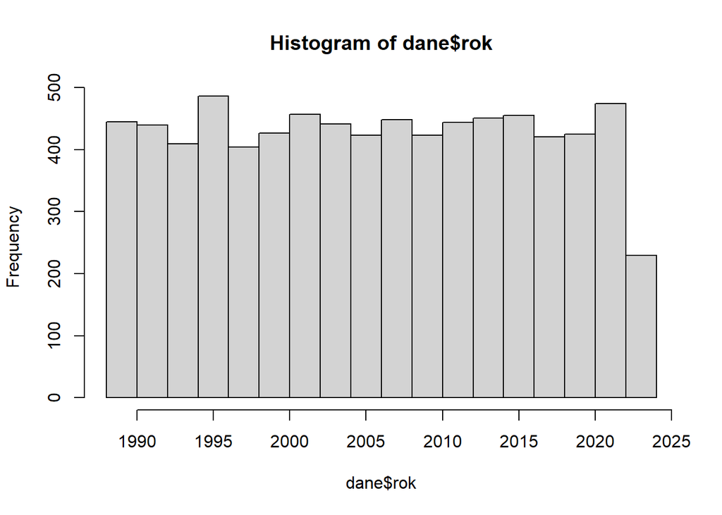

```r
# Histogram zmiennej 'rok'
hist(dane$rok)
```

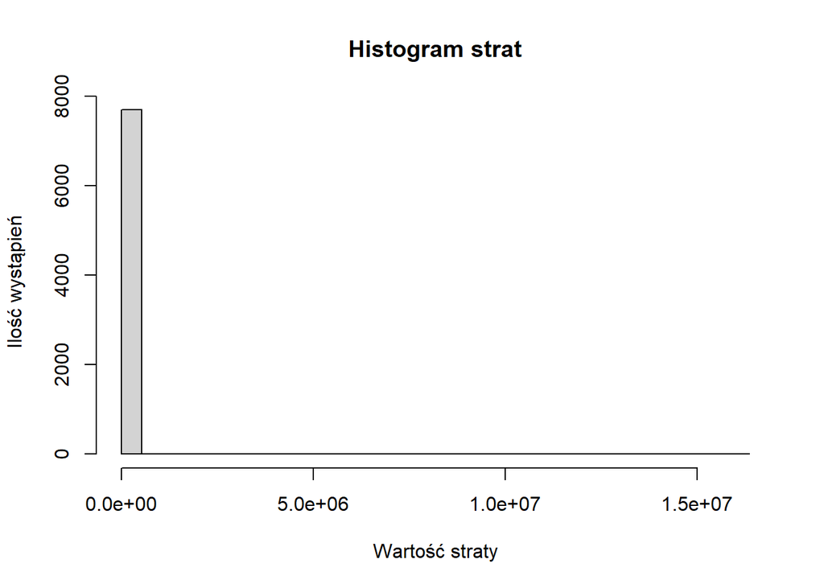

```r
# Histogram zmiennej 'strata'

max_strata <- max(dane$strata)
num_bins <- 32
hist(dane$strata, breaks = seq(0, max_strata, length.out = num_bins),
     main = "Histogram strat", xlab = "Wartość straty", ylab = "Ilość wystąpień")
```

Jak można zauważyć, dane dotyczą lat 1989-2023. Przedstawiają wartość wyrządzonej szkody oraz rodzaj wydarzenia. Wydarzenia jakie dane opisują są opisane jako:

- **Buss_Distr** - Business Disruption and System Failures (Zakłócenia działalności i awarie systemów)
- **Com_Ban** - Clients, Products and Business Practices (Klienci, produkty i praktyki biznesowe)
- **Damage** - Damage to Physical Assets (Uszkodzenie aktywów fizycznych)
- **Empl_Pract** - Employment Practices and Workplace Safety (Praktyki zatrudnienia i bezpieczeństwo w miejscu pracy)
- **Execut_Del** - Execution, Delivery and Process Management (Realizacja, dostawa i zarządzanie procesami)
- **External_Fr** - External Fraud (Oszustwa zewnętrzne)
- **Internal_Fr** - Internal Fraud (Oszustwa wewnętrzne)

Na histogramie przedstawiającym ilość zdarzeń w poszczególnych latach, wydaje się, że ostatni rok miał drastyczny spadek do około połowy wystąpień w porównaniu do lat poprzednich, jednakże w rzeczywistości, dane przedstawiane w słupkach zostały pogrupowane po dwa lata, a ostatni słupek przedstawia dane wyłącznie za rok 2023, co zakłamuje widok tych danych. Mając to na uwadzę, można wywnioskować, że średnio co rok występuje około 220 incydentów przynoszących straty.

Histogram strat ukazuje, jak bardzo straty są scentralizowane w okolicy niewielkich kwot. Jest ich tak nieproporcjonalnie dużo, że nie widać przy nich pozostałych słupków.

Celem dalszej analizy, pogrupowałem dane względem roku i linii. Poniżej znajduje się kilka przykładowych wartości:

```r
# Grupowanie danych po roku i linii, a następnie obliczenie sumy strat
czestosc_strat <- dane %>%
  group_by(rok, linia) %>%
  summarise(srednie_straty = mean(strata), ilosc_zdarzen = n())
```

[output not shown]

```r
head(czestosc_strat)
```

```
## # A tibble: 6 × 4
## # Groups:   rok [1]
##     rok linia       srednie_straty ilosc_zdarzen
##   <int> <chr>                <dbl>         <int>
## 1  1989 Buss_Distr            10               9
## 2  1989 Com_Ban               10.3            17
## 3  1989 Damage              3560.             15
## 4  1989 Empl_Pract         39124.             59
## 5  1989 Execut_Del            21.6            15
## 6  1989 External_Fr         4145.              9
```

Następnie stworzyłem wykres, przedstawiający zmiany ilości wydarzeń na przestrzeni lat pomiędzy różnymi typami wydarzeń.

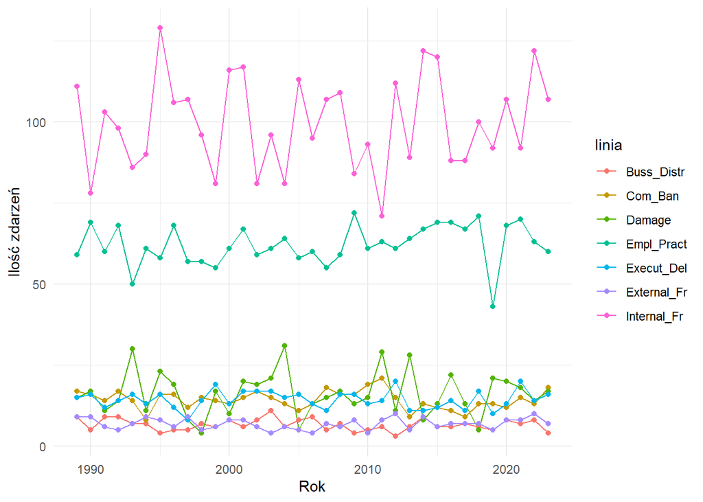

```r
# Tworzenie wykresów liniowych dla każdej unikatowej wartości z kolumny "linia"
wykresy <- ggplot(data = czestosc_strat, aes(x = rok, y = ilosc_zdarzen, group = linia, color = linia)) +
  geom_line() +
  geom_point() +
  labs(x = "Rok", y = "Ilość zdarzeń") +
  theme_minimal()

print(wykresy)
```

Powyższy wykres, pokazuje, że na przestrzeni wielu lat nie wystąpiła żadna istotna zmiana ilości zdarzeń (trend jest poziomy), a wszelkie wahania są krótkoterminowe. Z tego też powodu, w przyszłej estymacji ilości zdarzeń, nie będę uwzględniał trendów.

Następnie stowrzyłem kilka wykresów, przedstawiające zmianę średnich wartości straty na przestrzeni lat. Każdy z wykresów, dotyczy danych różnych rodzajów wydarzeń generujących straty. Uczyniłem tak dlatego, że wykres ze wszystkimi danymi był nieczytelny przez wartości odstające, których nie chciałem eliminować.

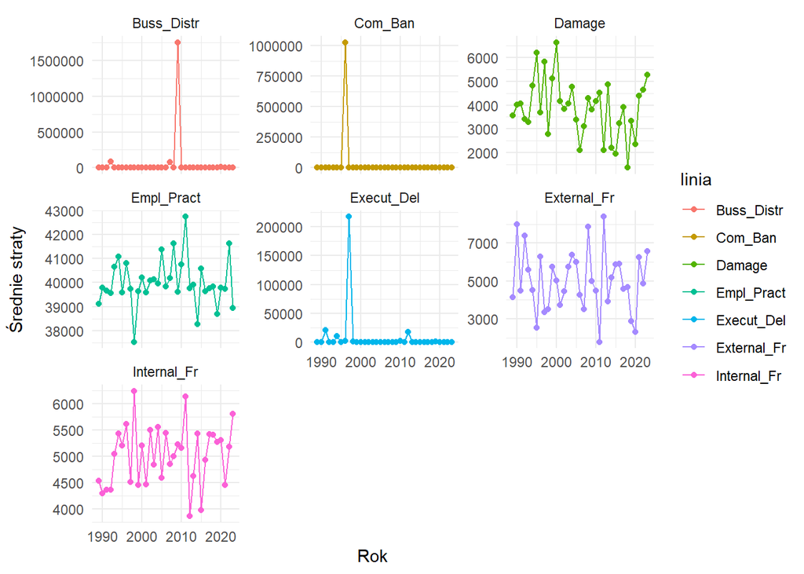

```r
# Tworzenie wykresów liniowych dla każdej unikatowej wartości z kolumny "linia"
wykresy <- ggplot(data = czestosc_strat, aes(x = rok, y = srednie_straty, group = linia, color = linia)) +
  geom_line() +
  geom_point() +
  labs(x = "Rok", y = "Średnie straty") +
  theme_minimal() +
  facet_wrap(~ linia, scales = "free_y")

print(wykresy)
```

Najbardziej wyróżniają się trzy wykresy: Buss_Distr, Com_Ban i Execut_Del. Cechują się one ogólnie bardzo niskimi średnimi, ale pojedyncze lata spowodowały bardzo duże straty. Pozostałe wykresy oscylują w okolicy jakiejś średniej z większymi lub mniejszymi wahaniami. Zazwyczaj ich średnie są niskie i wahają się od 3.000 do 6.000zł. Wyjątkiem jest Empl_Pract, gdzie średnie wahają się od 38.000 do 43.000zł.

Analizując te wykresy, można się zastanowić, czy Damage wykazuje małą tendencję do spadkowych średnich wartości straty. Z tego też powodu, przepisałem dane do excela, narysowałem tam linię trendu z wyznaczeniem funkcji trendu. Okazało się, że roczny spadek wartości straty wynosi około 30,3zł, co jest wartością mało istotną. Pomimo to, wyliczyłem na podstawie tej linii trendu, przypadającą wartość trendu dla następnego roku, która wyniosła około 3 317,8zł. Na podstawie tych danych, można wyliczyć, że spadek roczny nie przekracza 1% więc według mnie jest to trend pomijalny. Jeżeli nie zapomnę, to załączę plik excela wraz z tym dokumentem. Jest to jedyny wykres, który przedstawia potencjalny trend w zmianach tych wartości. Weryfikację trendów pozostałych wykresów dokonałem metodą na oko.

Do dalszej pracy pogrupowałem dane względem przyczyny wystąpienia kosztu. Dane przedstawiają się w następujący sposób:

```r
# Grupowanie i liczenie wystąpień dla każdej linii
grouped_data <- dane %>%
  group_by(linia) %>%
  summarise(count = n(),
            min_strata = min(strata, na.rm = TRUE),
            max_strata = max(strata, na.rm = TRUE))

print(grouped_data)
```

```
## # A tibble: 7 × 4
##   linia       count min_strata max_strata
##   <chr>       <int>      <dbl>      <dbl>
## 1 Buss_Distr    231       10     7011987.
## 2 Com_Ban       499       10    16362367.
## 3 Damage        567       27.2     28035
## 4 Empl_Pract   2174    15548.      63946.
## 5 Execut_Del    502       10     1742325.
## 6 External_Fr   242       22.7     27244.
## 7 Internal_Fr  3487       10       37102.
```

Następnie stworzyłem histogramy przedstawiające rozkład wartości straty i ich ilości wystąpień, rozdzielając przyczyny wystąpień owych strat. Uwzględniłem dane ze wszystkich dostępnych lat, gdyż nie zauważyłem żadnego istotnego trendu, ani żadnego innego czynnika mającego wpływ na te dane. Jedynie zastanawiałem się nad danymi grupy Damage, jednakże małe zmiany linii trendu w połączeniu z treścią polecenia, przekonały mnie, do uwzględnienia wszystkich lat do dopasowania rozkładu. Owe rozkłady wyglądają następująco:

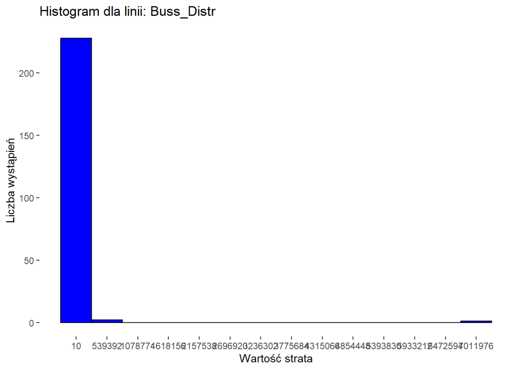

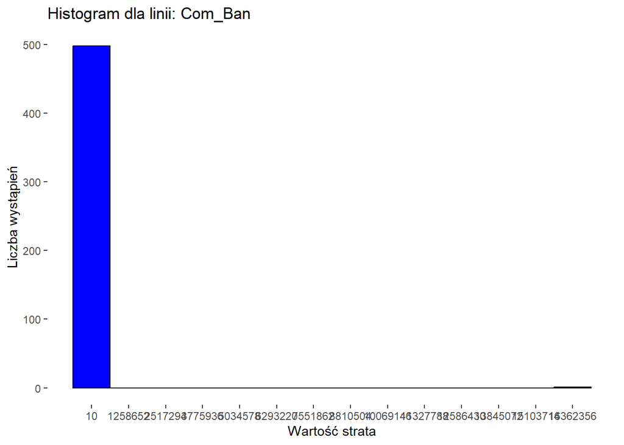

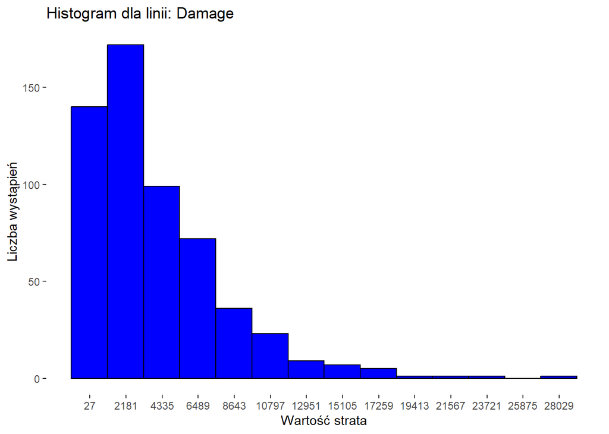

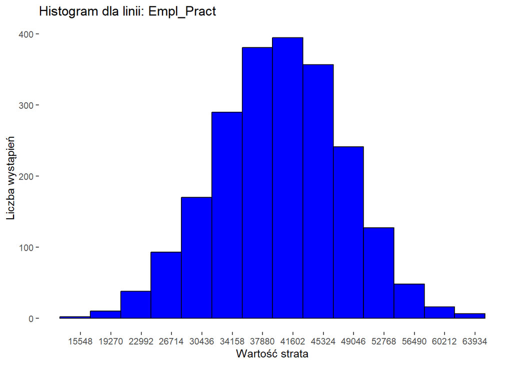

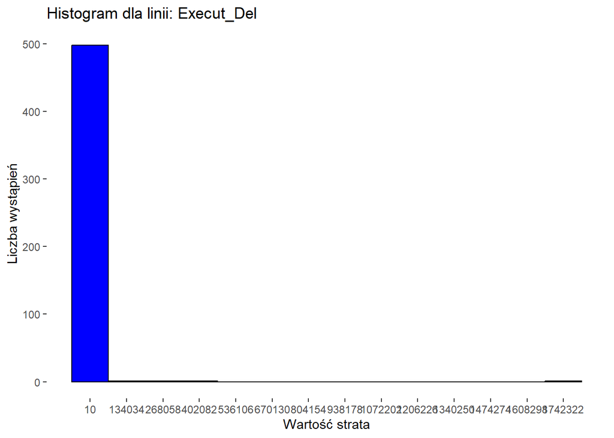

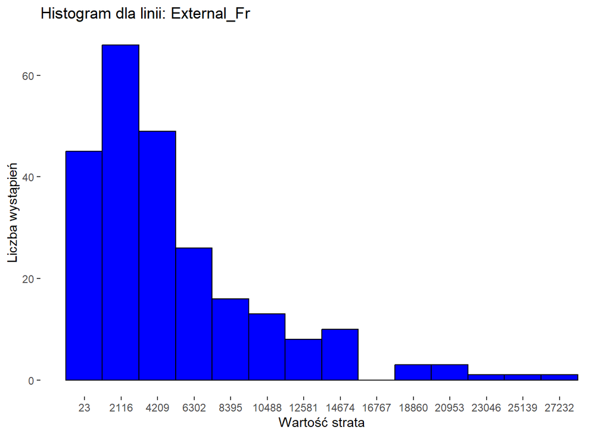

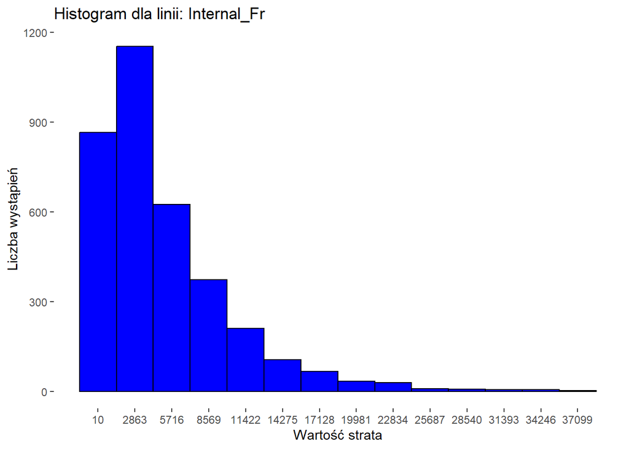

```r
#wziac chi kwadrat do tych pionowych slupkow, zobaczyc ktory ma najwieksze p value i zalozyc ze moze byc ten pomimo ze wyjdzie ze nie.
# Tworzenie histogramów dla każdej linii
for (i in 1:nrow(grouped_data)) {
  hist_data <- dane %>%
    filter(linia == grouped_data$linia[i]) %>%
    pull(strata)

  min_val <- grouped_data$min_strata[i]
  max_val <- grouped_data$max_strata[i]

  hist <- ggplot() +
    geom_histogram(data = data.frame(strata = hist_data), aes(x = strata), binwidth = (max_val - min_val)/13, fill = "blue", color = "black") +
    ggtitle(paste("Histogram dla linii:", grouped_data$linia[i])) +
    labs(x = "Wartość strata", y = "Liczba wystąpień") +
    scale_x_continuous(breaks = seq(min_val, max_val, by = as.integer((max_val - min_val)/13)), labels = function(x) round(x)) +
    theme(panel.background = element_rect(fill = "white"))

  print(hist)
}
```

Z powyższych rozkładów, widać nietypowe kształty w dwóch pierwszych wykresach i histogramie Execut_Del. Mają one bardzo dużo wartości bardzo małcyh i marginalne ilości innych bardzo dużych wartości. Dodatkowo, względem pozostałych mają największe wartości maksymalne. Porównywalnie często występującym rozkładem jest rozkład, gdzie najwięcej wystąpień jest w nieco większym segmencie niż minimalny, po którym następuje gwałtowny spadek wartości z powstającym długim ogonem. Jedynie histogram Empl_Pract wygląda na rozkład normalny.

## Za pomocą logiki lub/oraz dostępnych testów zgodności dopasować możliwie najlepszy rozkład liczby zdarzeń operacyjnych oraz rozkład ich dotkliwości. Ustalić parametry wybranych rozkładów.

Ze względu na wyglądy powyższych histogramów, dopasuję parametry do rozkładów chi kwadrat, normalnego i dwumianowego, a następnie przetestuję testem Kołmogorowa-Smirnowa

```r
parametry <-c(1:7)
for (i in 1:nrow(grouped_data))
{
  hist_data <- dane %>%
    filter(linia == grouped_data$linia[i]) %>%
    pull(strata)
  print(paste("Testujemy", grouped_data$linia[i]))
  print(paste("o liczebności", length(hist_data)))

  print("dla rozkładu chi kwadrat")
  fit <- fitdist(round(hist_data), "chisq", start = list(df = 1)) #chi kwadrat
  print("Test Kołmogorowa-Smirnowa zwraca rezultat:")
  print(ks.test(hist_data,function(q)pchisq(q,fit$estimate)))
  print("dla rozkładu dwumianowego")
  fit <- fitdist(round(hist_data),"nbinom")
  print("Test Kołmogorowa-Smirnowa zwraca rezultat:")
  print(ks.test(hist_data,function(q)pnbinom(q,size=fit$estimate[1],mu=fit$estimate[2]))) #dwumianowy
  print("dla rozkładu normalnego")
  fit <- fitdist(hist_data, "norm")
  print("Test Kołmogorowa-Smirnowa zwraca rezultat:")
  print(ks.test(hist_data,function(q)pnorm(q,mean=fit$estimate[1],sd=fit$estimate[2]))) #normalny

  if(i==1 || i==2 || i==5)
  {
    #print("dla rozkładu chi kwadrat")
    fit <- fitdist(round(hist_data), "chisq", start = list(df = 1)) #chi kwadrat
    #print("Test Kołmogorowa-Smirnowa zwraca rezultat:")
    #print(ks.test(hist_data,function(q)pchisq(q,fit$estimate)))
  }
  else if(i==3 || i==6 || i==7)
  {
    #print("dla rozkładu dwumianowego")
    fit <- fitdist(round(hist_data),"nbinom")
    #print("Test Kołmogorowa-Smirnowa zwraca rezultat:")
    #print(ks.test(hist_data,function(q)pnbinom(q,size=fit$estimate[1],mu=fit$estimate[2]))) #dwumianowy
  }
  else if(i==4)
  {
    #print("dla rozkładu normalnego")
    fit <- fitdist(hist_data, "norm")
    #print("Test Kołmogorowa-Smirnowa zwraca rezultat:")
    #print(ks.test(hist_data,function(q)pnorm(q,mean=fit$estimate[1],sd=fit$estimate[2]))) #normalny
  }

  parametry[i] <- fit

}
```

```
## [1] "Testujemy Buss_Distr"
## [1] "o liczebności 231"
## [1] "dla rozkładu chi kwadrat"
## [1] "Test Kołmogorowa-Smirnowa zwraca rezultat:"
##
##  Asymptotic one-sample Kolmogorov-Smirnov test
##
## data:  hist_data
## D = 0.79327, p-value < 2.2e-16
## alternative hypothesis: two-sided
##
## [1] "dla rozkładu dwumianowego"
## [1] "Test Kołmogorowa-Smirnowa zwraca rezultat:"
##
##  Asymptotic one-sample Kolmogorov-Smirnov test
##
## data:  hist_data
## D = 0.53906, p-value < 2.2e-16
## alternative hypothesis: two-sided
##
## [1] "dla rozkładu normalnego"
## [1] "Test Kołmogorowa-Smirnowa zwraca rezultat:"
##
##  Asymptotic one-sample Kolmogorov-Smirnov test
##
## data:  hist_data
## D = 0.50673, p-value < 2.2e-16
## alternative hypothesis: two-sided
##
## [1] "Testujemy Com_Ban"
## [1] "o liczebności 499"
## [1] "dla rozkładu chi kwadrat"
## [1] "Test Kołmogorowa-Smirnowa zwraca rezultat:"
##
##  Asymptotic one-sample Kolmogorov-Smirnov test
##
## data:  hist_data
## D = 0.59885, p-value < 2.2e-16
## alternative hypothesis: two-sided
##
```

[output cut: 147 more lines]

```
##
##  Asymptotic one-sample Kolmogorov-Smirnov test
##
## data:  hist_data
## D = 0.0090385, p-value = 0.9382
## alternative hypothesis: two-sided
##
## [1] "dla rozkładu normalnego"
## [1] "Test Kołmogorowa-Smirnowa zwraca rezultat:"
##
##  Asymptotic one-sample Kolmogorov-Smirnov test
##
## data:  hist_data
## D = 0.16024, p-value < 2.2e-16
## alternative hypothesis: two-sided
```

Owe badanie spowodowało, że do następujących rodzajów zastosuję rozkłady:

- **Buss_Distr** - rozkład chi kwadrat
- **Com_Ban** - rozkład chi kwadrat
- **Damage** - rozkład dwumianowy
- **Empl_Pract** - rozkład normalny
- **Execut_Del** - rozkład chi kwadrat
- **External_Fr** - rozkład dwumianowy
- **Internal_Fr** - rozkład dwumianowy

W kolejnym etapie, sprawdzam wyglądy rozkładów częstości wystąpień szkód.

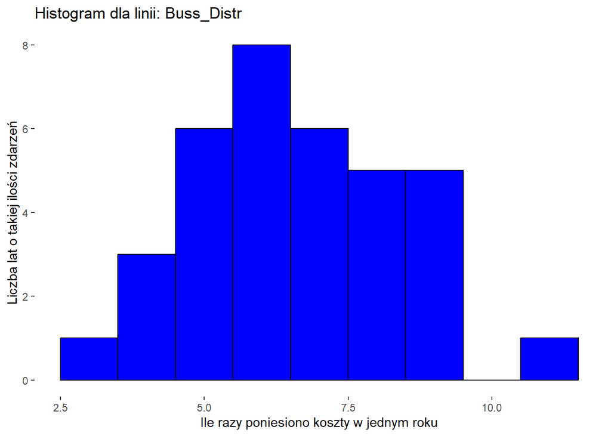

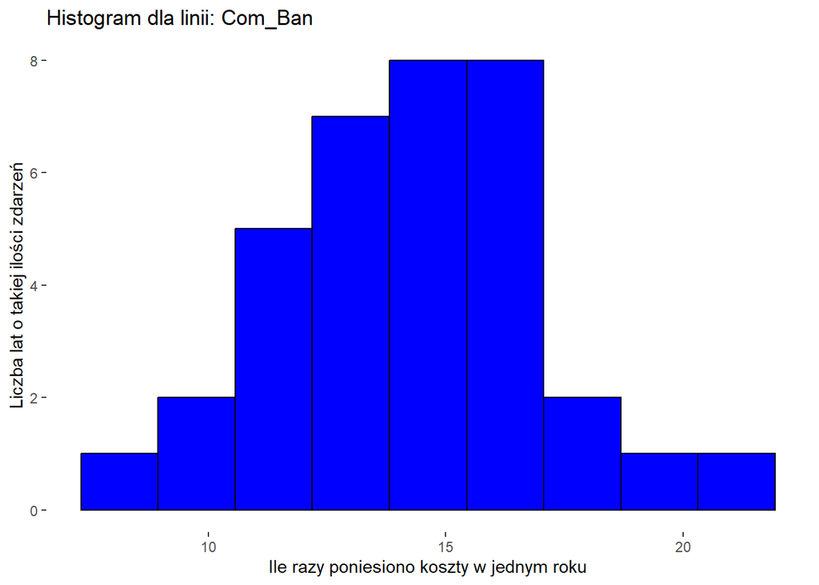

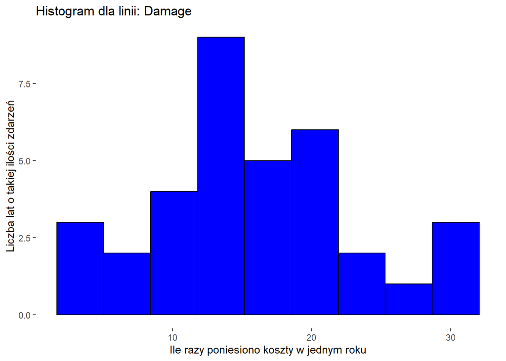

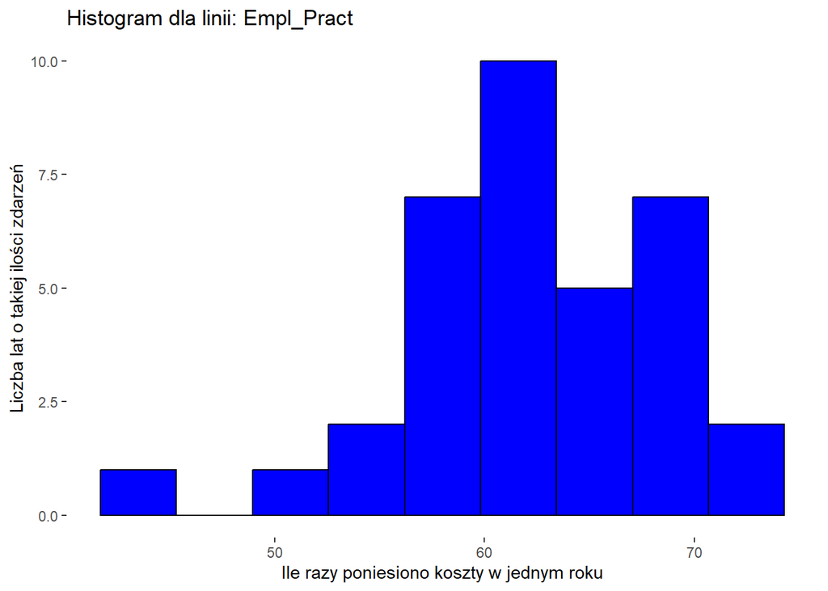

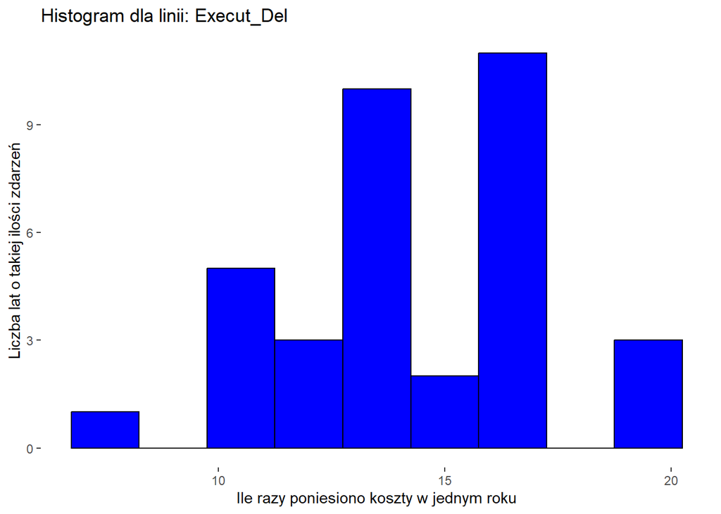

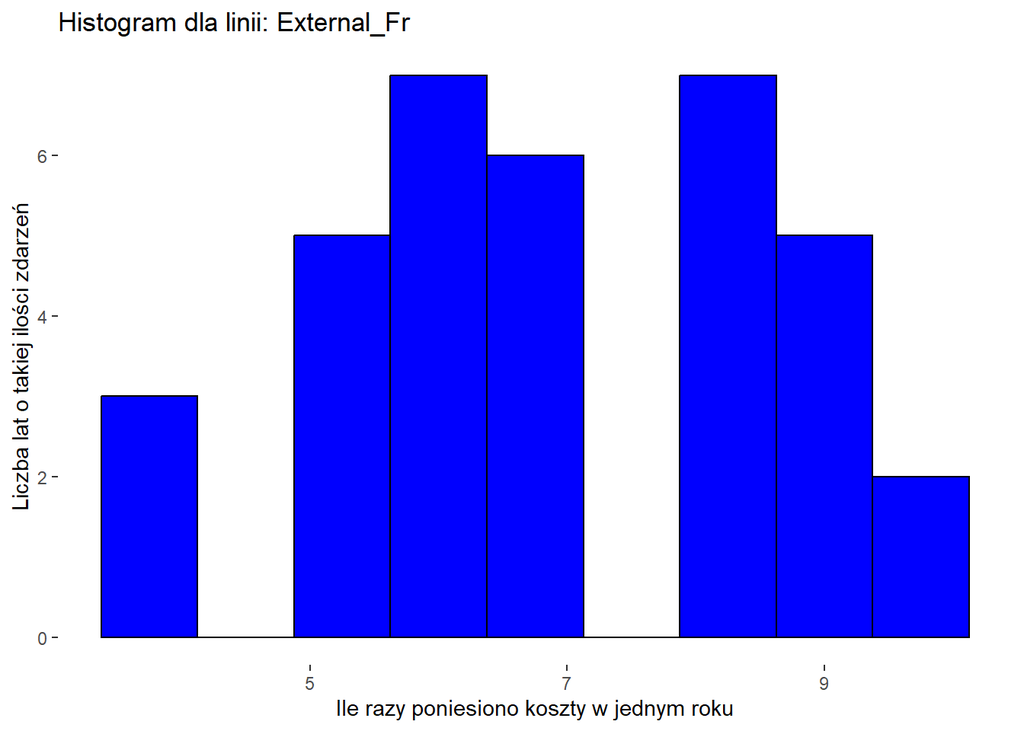

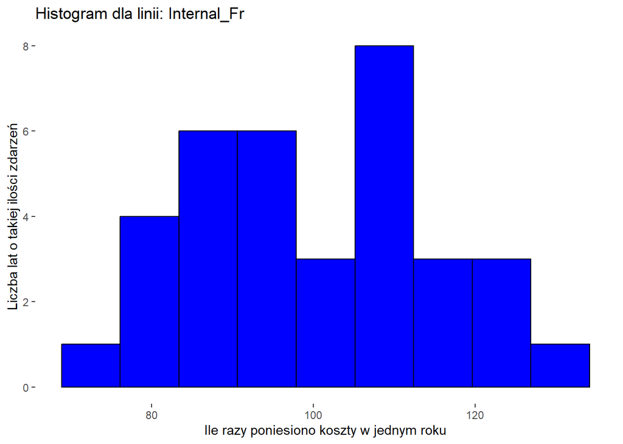

```r
  full_hist_data <- dane %>%
    group_by(linia,rok) %>%
    summarise(count = n(),
            min_strata = min(strata, na.rm = TRUE),
            max_strata = max(strata, na.rm = TRUE))
for (i in 1:nrow(grouped_data)) {
  hist_data <- full_hist_data %>%
    filter(linia == grouped_data$linia[i])

  hist <- ggplot() +
    geom_histogram(data = hist_data, aes(x = count), binwidth = (max(hist_data$count)-min(hist_data$count))/8, fill = "blue", color = "black") +
    ggtitle(paste("Histogram dla linii:", grouped_data$linia[i])) +
    labs(x = "Ile razy poniesiono koszty w jednym roku", y = "Liczba lat o takiej ilości zdarzeń") +
    theme(panel.background = element_rect(fill = "white"))

  print(hist)
}
```

Wszystkie wyglądają mi na rozkłady normalne, dlatego też sprawdzam ich parametry i testuję testem Kołmogorowa-Smirnowa.

```r
parametry_dla_ilosci_zdarzen <-c(1:7)
for (i in 1:nrow(grouped_data))
{
  wektor <- czestosc_strat %>%
    filter(linia == grouped_data$linia[i]) %>%
    pull(ilosc_zdarzen)

  fit <- fitdist(wektor, "norm")
  print(ks.test(wektor,function(q)pnorm(q,mean=fit$estimate[1],sd=fit$estimate[2])))
  parametry_dla_ilosci_zdarzen[i] <- fit
}
```

```
##
##  Asymptotic one-sample Kolmogorov-Smirnov test
##
## data:  wektor
## D = 0.14654, p-value = 0.4399
## alternative hypothesis: two-sided
##
##
##  Asymptotic one-sample Kolmogorov-Smirnov test
##
## data:  wektor
## D = 0.1006, p-value = 0.8707
## alternative hypothesis: two-sided
##
##
##  Asymptotic one-sample Kolmogorov-Smirnov test
##
## data:  wektor
## D = 0.084773, p-value = 0.963
## alternative hypothesis: two-sided
##
##
##  Asymptotic one-sample Kolmogorov-Smirnov test
##
## data:  wektor
## D = 0.13028, p-value = 0.5924
## alternative hypothesis: two-sided
##
##
##  Asymptotic one-sample Kolmogorov-Smirnov test
##
## data:  wektor
## D = 0.12692, p-value = 0.6257
## alternative hypothesis: two-sided
##
##
##  Asymptotic one-sample Kolmogorov-Smirnov test
##
## data:  wektor
## D = 0.14099, p-value = 0.4898
## alternative hypothesis: two-sided
##
##
##  Asymptotic one-sample Kolmogorov-Smirnov test
##
## data:  wektor
## D = 0.10112, p-value = 0.8666
## alternative hypothesis: two-sided
```

W związku z tym, że rozkłady normalne z wyestymowanymi parametrami przeszły testy, przyjmę te rozkłady do dalszej pracy.

# Stosując AMA należy wyznaczyć roczny 99,9% OpVaR oraz OpES dla danego banku.

## Znając rozkład częstości i rozkład wartości strat (ich parametry) wygenerować 20000 scenariuszy i wyznaczyć symulacyjny rozkład strat.

Następnie tworzę 20 000 scenariuszy, w następujący sposób. Dla każdego typu strat generuję liczbę zdarzeń zgodnie z rozkładem dopasowanym dla estymowanego zdarzenia. Następnie losuję wartości dla tego zdarzenia w wyestymowanej liczbie, zgodnie z dopasowanym rozkładem. Dodatkowo sprawdzam każdą wylosowaną wartość. Jeżeli jest mniejsza lub równa 0,5zł, to wtedy zamieniam ją na najczęściej występującą liczbę, czyli 10. Ze względu, że prawdopodobieństwo zajścia takiego zjawiska jest bardzo małe i w skali wszystkich scenariuszy zajdzie pewnie kilkanaście razy, to pozwolę sobie na takie uproszczenie.

```r
scenariusze <- vector("list", length = 20000)
for(numer_scenariusza in 1:20000)
{
  scenariusze[[numer_scenariusza]] <- vector("list", length = 7)

  for (i in 1:nrow(grouped_data))
  {
    ilosc_zdarzen <- round(rnorm(1, mean = parametry_dla_ilosci_zdarzen[[i]][1], sd = parametry_dla_ilosci_zdarzen[[i]][2]),0)
    while(ilosc_zdarzen<0)
    {
      ilosc_zdarzen <- round(rnorm(1, mean = parametry_dla_ilosci_zdarzen[[i]][1], sd = parametry_dla_ilosci_zdarzen[[i]][2]),0)
    }
    if(i==1 || i==2 || i==5)
    {
      x<- round(rchisq(n=ilosc_zdarzen,df=parametry[[i]][1]), 2)
      x <- ifelse(x <= 0.5, 10, x)
      scenariusze[[numer_scenariusza]][[i]] <- x
    }
    else if(i==3 || i==6 || i==7)
    {
      x <- round(rnbinom(n=ilosc_zdarzen,size = parametry[[i]][1],mu = parametry[[i]][2]),2)
      x <- ifelse(x <= 0.5, 10, x)
      scenariusze[[numer_scenariusza]][[i]] <- x
    }
    else if(i==4)
    {
      x <- round(rnorm(ilosc_zdarzen,mean = parametry[[i]][1],sd = parametry[[i]][2]), 2)
      x <- ifelse(x <= 0.5, 10, x)
      scenariusze[[numer_scenariusza]][[i]] <- x
    }
  }
}
```

## Na podstawie wygenerowanych danych wyznaczyć 99,9% OpVaR oraz OpES.

Następnie sumuję i sortuję wyestymowane dane. Analizując powstały zestaw danych, można zauważyć, że w zsumowanych kosztach po rodzaju w scenariuszu występują wartości zerowe. Jest to spowodowane tym, że dopuszczam do nie wystąpienia żadnej szkody. Następnie wyznaczam OpVar i OpEs na podstawie posortowanych danych oznaczających sumę kosztów całego scenariusza. OpVar jest 19 980 elementem tej listy, natomast OpES jest średnią wartością z tej listy elementów od 19 980 włącznie.

```r
wyestymowane_i_zsumowane_wartosci <- vector("list", length = 20000)
for(numer_scenariusza in 1:20000)
{
  wyestymowane_i_zsumowane_wartosci[[numer_scenariusza]] <- c(sum(scenariusze[[numer_scenariusza]][[1]]),sum(scenariusze[[numer_scenariusza]][[2]]),sum(scenariusze[[numer_scenariusza]][[3]]),sum(scenariusze[[numer_scenariusza]][[4]]),sum(scenariusze[[numer_scenariusza]][[5]]),sum(scenariusze[[numer_scenariusza]][[6]]),sum(scenariusze[[numer_scenariusza]][[7]])) #vector("list", length = 7)
  wyestymowane_i_zsumowane_wartosci[[numer_scenariusza]] <- c(wyestymowane_i_zsumowane_wartosci[[numer_scenariusza]],sum(wyestymowane_i_zsumowane_wartosci[[numer_scenariusza]]))

}

posortowane_wyestymowane_i_zsumowane_wartosci <- vector("list", length = 16)
for(i in 1:8)
{
  for(j in 1:20000)
  {
    if(j==1)
    {
      posortowane_wyestymowane_i_zsumowane_wartosci[[i]][j] <- c()
    }
    posortowane_wyestymowane_i_zsumowane_wartosci[[i]] <- c(posortowane_wyestymowane_i_zsumowane_wartosci[[i]], wyestymowane_i_zsumowane_wartosci[[j]][[i]])
    if(j==20000)
    {
      posortowane_wyestymowane_i_zsumowane_wartosci[[i]] <- sort(posortowane_wyestymowane_i_zsumowane_wartosci[[i]])
    }
  }
}

wszystkie_koszty <- c(posortowane_wyestymowane_i_zsumowane_wartosci[[8]])

print(paste("OpVar wynosi:",wszystkie_koszty[19980],"natomiast OpES wynosi:",mean(wszystkie_koszty[19980:20000])))
```

```
## [1] "OpVar wynosi: 3905450.62 natomiast OpES wynosi: 3975105.83047619"
```

Otrzymany wynik, oznacza, że na 99,9% koszta operacyjne w następnym roku nie przekroczą 3 905 450.62zł. Średnia wartość kosztów operacyjnych dla najgorszego 0,1% scenariuszy wynosi 3 975 105.83zł.

## Zastosować procedurę n razy i w efekcie wyznaczyć ostateczny OpVaR oraz OpES wraz z odchyleniem st.

Zapisuję te dane do wektora i powtarzam to badanie 49 razy otrzymując w sumie 50 wartości OpVar i OpEs.

```r
rezultaty_OpVar <- c(wszystkie_koszty[19980])
rezultaty_OpEs <- c(mean(wszystkie_koszty[19980:20000]))
for (rezultaty_koncowe_numer in 1:49) {
  scenariusze <- vector("list", length = 20000)
for(numer_scenariusza in 1:20000)
{
  scenariusze[[numer_scenariusza]] <- vector("list", length = 7)

  for (i in 1:nrow(grouped_data))
  {
    ilosc_zdarzen <- round(rnorm(1, mean = parametry_dla_ilosci_zdarzen[[i]][1], sd = parametry_dla_ilosci_zdarzen[[i]][2]),0)
    while(ilosc_zdarzen<0)
    {
      ilosc_zdarzen <- round(rnorm(1, mean = parametry_dla_ilosci_zdarzen[[i]][1], sd = parametry_dla_ilosci_zdarzen[[i]][2]),0)
    }
    if(i==1 || i==2 || i==5)
    {
      scenariusze[[numer_scenariusza]][[i]] <- round(rchisq(n=ilosc_zdarzen,df=parametry[[i]][1]), 2)
    }
    else if(i==3 || i==6 || i==7)
    {
      #print(paste("size =", parametry[[i]][1], "mu =",parametry[[i]][2]))
      scenariusze[[numer_scenariusza]][[i]] <- round(rnbinom(n=ilosc_zdarzen,size = parametry[[i]][1],mu = parametry[[i]][2]),2)
    }
    else if(i==4)
    {
      scenariusze[[numer_scenariusza]][[i]] <- round(rnorm(ilosc_zdarzen,mean = parametry[[i]][1],sd = parametry[[i]][2]), 2)
    }
  }
}
  wyestymowane_i_zsumowane_wartosci <- vector("list", length = 20000)
for(numer_scenariusza in 1:20000)
{
  wyestymowane_i_zsumowane_wartosci[[numer_scenariusza]] <- c(sum(scenariusze[[numer_scenariusza]][[1]]),sum(scenariusze[[numer_scenariusza]][[2]]),sum(scenariusze[[numer_scenariusza]][[3]]),sum(scenariusze[[numer_scenariusza]][[4]]),sum(scenariusze[[numer_scenariusza]][[5]]),sum(scenariusze[[numer_scenariusza]][[6]]),sum(scenariusze[[numer_scenariusza]][[7]])) #vector("list", length = 7)
  wyestymowane_i_zsumowane_wartosci[[numer_scenariusza]] <- c(wyestymowane_i_zsumowane_wartosci[[numer_scenariusza]],sum(wyestymowane_i_zsumowane_wartosci[[numer_scenariusza]]))

}

posortowane_wyestymowane_i_zsumowane_wartosci <- vector("list", length = 16)
for(i in 1:8)
{
  for(j in 1:20000)
  {
    if(j==1)
    {
      posortowane_wyestymowane_i_zsumowane_wartosci[[i]][j] <- c()
    }
    posortowane_wyestymowane_i_zsumowane_wartosci[[i]] <- c(posortowane_wyestymowane_i_zsumowane_wartosci[[i]], wyestymowane_i_zsumowane_wartosci[[j]][[i]])
    if(j==20000)
    {
      posortowane_wyestymowane_i_zsumowane_wartosci[[i]] <- sort(posortowane_wyestymowane_i_zsumowane_wartosci[[i]])
    }
  }
}

wszystkie_koszty <- c(posortowane_wyestymowane_i_zsumowane_wartosci[[8]])

rezultaty_OpVar <- c(rezultaty_OpVar,wszystkie_koszty[19980])
rezultaty_OpEs <- c(rezultaty_OpEs,mean(wszystkie_koszty[19980:20000]))

}
print(paste("Średnio OpVar wynosi:",mean(rezultaty_OpVar),"i posiada odchylenie standardowe:",sd(rezultaty_OpVar)))
```

```
## [1] "Średnio OpVar wynosi: 3917836.4948 i posiada odchylenie standardowe: 19491.0756576096"
```

```r
print(paste("Średnio OpES wynosi:",mean(rezultaty_OpEs),"i posiada odchylenie standardowe:",sd(rezultaty_OpEs)))
```

```
## [1] "Średnio OpES wynosi: 3988751.07488571 i posiada odchylenie standardowe: 21693.4797929422"
```

Można by założyć, że bezpieczne na 99,9% dla przedsiębiorstwa byłoby przygotowanie budżetu na koszty operacyjne w wysokości 3 917 836.49zł. Warto także, żeby firma posiadała jakieś zabezpieczenie budżetu nawet na (3988751.07 + 21693.48 =) 4 010 444.55zł kosztów operacyjnych w przypadku czarnego scenariusza, jednakże…

Tutaj pojawia się pewien problem. Maksymalna strata jednego zdarzenia wynosiła ponad 16 mln, jednak w wyestymowanych OpVarach wartości są w okolicy 4 mln i posiadają niskie odchylenie standardowe. To spowodowało, że drążyłem temat głębiej. Oto wynik 6 największych strat w danym roku:

```r
library(dplyr)
group_data2 <- dane %>%
    group_by(rok) %>%
    summarise(SumaStratWRoku = sum(strata), Zdarzen = n())
print(group_data2[order(-group_data2$SumaStratWRoku), ][1:6,])
```

```
## # A tibble: 6 × 3
##     rok SumaStratWRoku Zdarzen
##   <int>          <dbl>   <int>
## 1  1996      19932924.     232
## 2  2009      10393167.     213
## 3  1997       4566641.     206
## 4  1992       4003379.     225
## 5  2020       3435113.     236
## 6  2018       3408095.     219
```

Dane te przedstawiają, że aż w czterech latach suma strat przekroczyła obliczoną wartość OpVar dla poziomu ufności równego 99,9%. Prawdopodobieństwo zajścia takiego zjawiska dla zbioru 35 lat jest bardzo niskie, więc można poddać w wątpliwość jakość wykonanego projektu.

Dlaczego do tego doszło? Jest to wina zastosowanych rozkładów chi kwadrat. Są trzy typy szkód, które mają bardzo duże prawdopodobieństwa szkód niewielkich i bardzo niewielkie prawdopodobieństwa szkód największych. Dopiero jedenasta strata (patrząc od największych) nie pochodzi z dziwnego rozkładu, do którego przypisałem rozkład chi kwadrat. (Na dowód poniżej przedstawiam 12 największych strat z otrzymanych danych)

```r
print(dane[order(-dane$strata), ][1:12,])
```

```
##       rok      strata      linia
## 349  1996 16362367.01    Com_Ban
## 142  2009  7011987.37 Buss_Distr
## 3592 1997  1742325.18 Execut_Del
## 32   1992   798266.47 Buss_Distr
## 133  2007   389940.93 Buss_Distr
## 3811 2012   339985.21 Execut_Del
## 3508 1991   242502.05 Execut_Del
## 3548 1994   126854.80 Execut_Del
## 209  2020    95719.13 Buss_Distr
## 346  1996    70746.70    Com_Ban
## 1829 1997    63946.18 Empl_Pract
## 1981 2000    63823.39 Empl_Pract
```

Celem ułatwienia sobie życia (i zalecenia prowadzącego), do estymacji dziwnych danych zastosowałem rozkład chi kwadrat, jednak do prawdziwej analizy dla przedsiębiorstwa, należałoby stworzyć własny rozkład na podstawie posiadanych danych, lub znaleźć już istniejący, lepiej dopasowany. Taka zmiana, spowodowała by, że niektóre z obliczanych 20 000 scenariuszy posiadałoby wartości porównywalne do tych największych, a być może nawet jeszcze istotnie większe, co spowodowało by istotny wzrost OpES i OpVaR. Owy wzrost byłby do takich wartości, że może jeden najgorszy dotychczasowy rok przekroczyłby wartość OpVar.

# zad 2 - Model mertona

## Szczegółowo i przystępnie wyjaśnić, na czym polega model Mertona

W modelu Mertona pożyczkobiorca jest postrzegany jako posiadacz różnych aktywów oraz dłużnik. Istotnym elementem modelu jest to, że wartość aktywów pożyczkobiorcy może oscylować w czasie.

Głównym założeniem modelu Mertona jest, że pożyczkobiorca zbankrutuje w momencie, gdy wartość jego aktywów spadnie poniżej wartości zadłużenia. Innymi słowy, jeśli wartość aktywów pożyczkobiorcy jest wystarczająco wysoka, aby pokryć jego zadłużenie, nie będzie on niewypłacalny. Jednak jeśli wartość jego aktywów spadnie poniżej poziomu zadłużenia, pożyczkobiorca zbankrutuje.

Dodatkowym założeniem jest, że kredytobiorca ogłasza upadłość w momencie zapadalności długu. Np. kiedy nadchodzi termin wykupu obligacji.

Model Mertona pozwala ocenić ryzyko kredytowe poprzez oszacowanie prawdopodobieństwa bankructwa pożyczkobiorcy w danym czasie. Wykorzystuje się do tego między innymi informacje o zmienności wartości aktywów oraz wartości zadłużenia pożyczkobiorcy. Ze względu, że główne założenie o momencie bankructwa bardzo przypomina system działania opcji na rynkach finansowych, to do wyliczenia prawdopodobieństwa bankructwa, model Mertona korzysta z modelu Blacka-Scholesa do wyceny opcji:

$$E_t = A_tN(d_1) - Le^{-r(T-t)}N(d_2)$$

gdzie

$$d_1 = \frac{\ln(A_t/L) + (r + (\sigma^2)/2)(T-t)}{\sigma\sqrt{T}}$$

$$d_2 = d_1 - \sigma\sqrt{T}$$

Następnie wyznaczamy prawdopodobieństwo niespłacenia długów przez kredytobiorcę ze wzoru:

$$N(-d_2) = 1 - N(d_2)$$

Celem wyznaczenia brakujących zmiennych stosuje się lemat ito. Otrzymujemy następujący układ równań:

$$\left\{
\begin{align*}
E_0 &= V_0N(d_1) - De^{-rT}N(d_2), \\
\sigma_{E}E_0 &= N(d_1)\sigma_{V}V_0
\end{align*}
\right.$$

Jedną z zalet modelu Mertona jest to, że umożliwia on uwzględnienie zmienności wartości aktywów pożyczkobiorcy, co może być istotne przy ocenie ryzyka kredytowego. Jednakże, model ten ma również swoje ograniczenia, takie jak założenie ciągłej zmienności, które mogą wpływać na dokładność jego prognoz. Ponadto, w praktyce, ocena ryzyka kredytowego oparta na modelu Mertona może być skomplikowana ze względu na potrzebę dysponowania dokładnymi danymi dotyczącymi aktywów i zadłużenia pożyczkobiorcy.